# PA1_template

amine

22 octobre 2017

# Assignement week 2

## Loading the data

```r
activity<-read.csv("activity.csv")
```

- transform date from factor to date

```r
activity$date<-as.Date(as.character(activity$date))
```

## Calculate the mean total number of steps taken per day

- aggregate data using date

```r
activityAggregated<-aggregate(steps~date,data=activity,FUN=sum,na.rm=TRUE)
```

- Histogram of the total number of steps taken each day

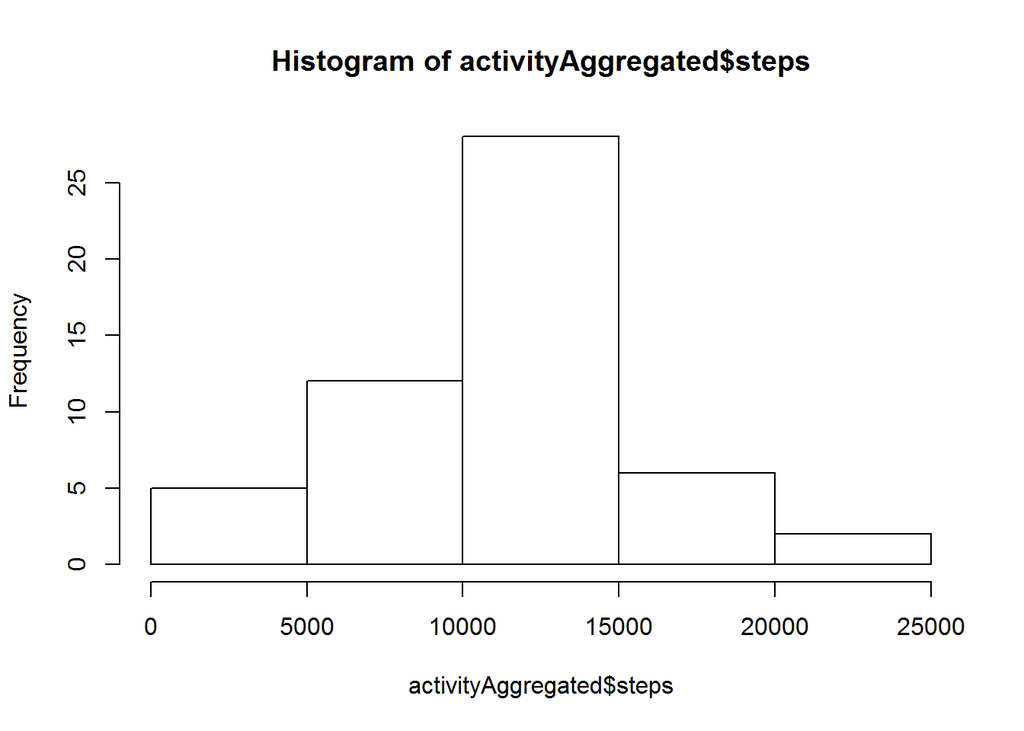

```r
hist(activityAggregated$steps)
```

- Calculate and report the **mean** and **median** total number of steps taken per day

```r
mean(activityAggregated$steps)
```

```
## [1] 10766.19
```

```r
median(activityAggregated$steps)
```

```
## [1] 10765
```

## Calculate the average daily activity pattern

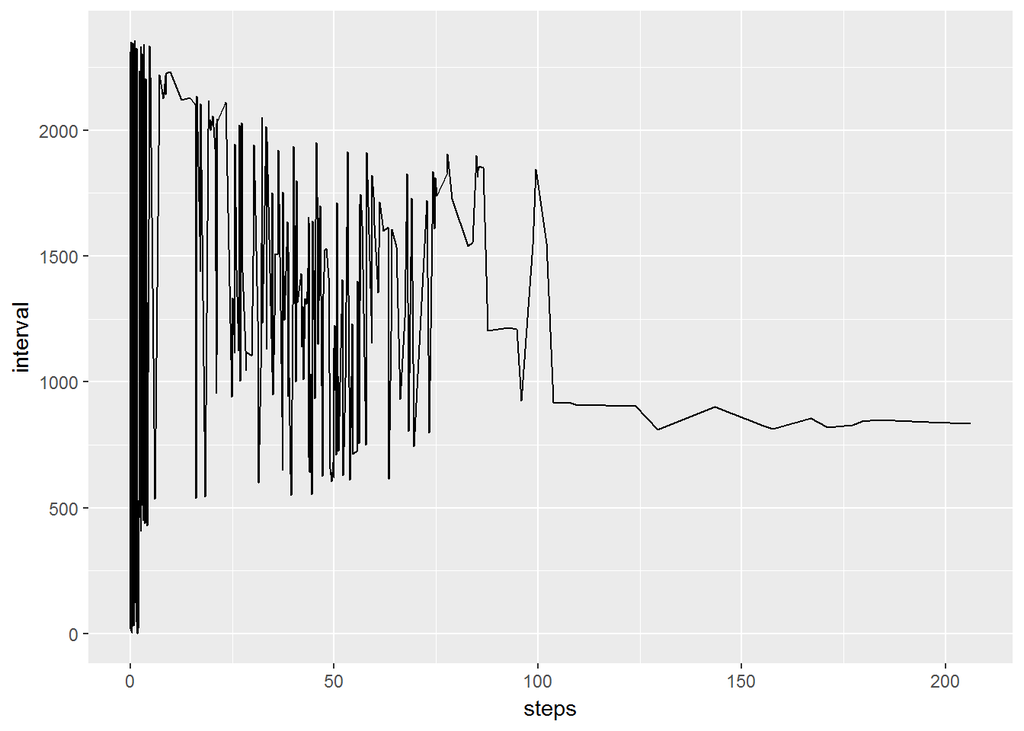

```r
activityDaily<-aggregate(steps~interval,data=activity,mean,na.rm=TRUE)
library(ggplot2)
qplot(steps,interval,data=activityDaily,geom ="line")
```

- Which 5-minute interval, on average across all the days in the dataset, contains the maximum number of steps?

```r
activityDaily[which.max(activityDaily$steps),]$interval
```

```
## [1] 835
```

The intervall is **835**

## Imputing missing values

- We are going to calculate total number of missing values in the dataset (i.e. the total number of rows with NAs)

```r
sum(is.na(activity$steps))
```

```
## [1] 2304
```

Total of NA in the data is **2304**.

```r
activityFilled<-activity
activityFilled[is.na(activity$steps),]$steps<-mean(activityDaily$steps)
```

- We are going now to plot an histogram of the total number of steps taken each day and Calculate and report the mean and median total number of steps taken per day.

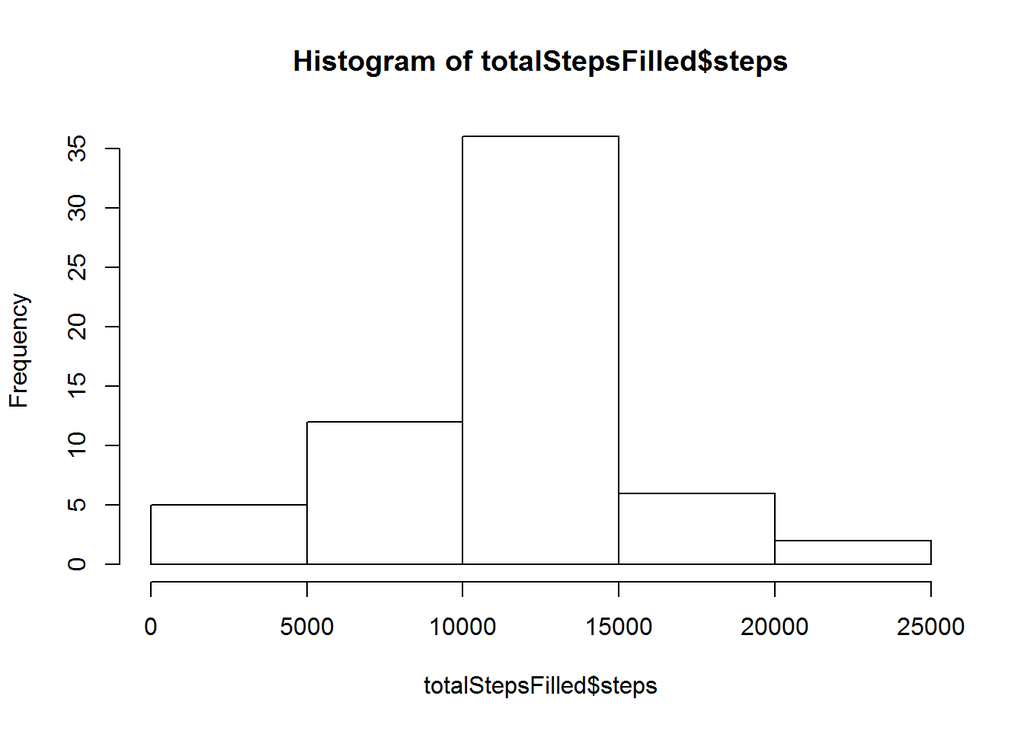

```r
totalStepsFilled<-aggregate(steps~date,data=activityFilled,sum)
hist(totalStepsFilled$steps)
```

```r
mean(totalStepsFilled$steps)
```

```
## [1] 10766.19
```

```r
median(totalStepsFilled$steps)
```

```
## [1] 10766.19
```

## Are there differences in activity patterns between weekdays and weekends?

- We will add a new factor into the data for week/weekends

```r
weekdays <- c('lundi', 'mardi', 'mercredi', 'jeudi', 'vendredi')
activityFilled$weekFator <- factor((weekdays(activityFilled$date) %in% weekdays),levels=c(FALSE, TRUE), labels=c('weekend', 'weekday'))
```

- We will now make a panel plot containing a time series plot (i.e. type = “l”) of the 5-minute interval and the average number of steps taken, averaged across all weekday days or weekend days

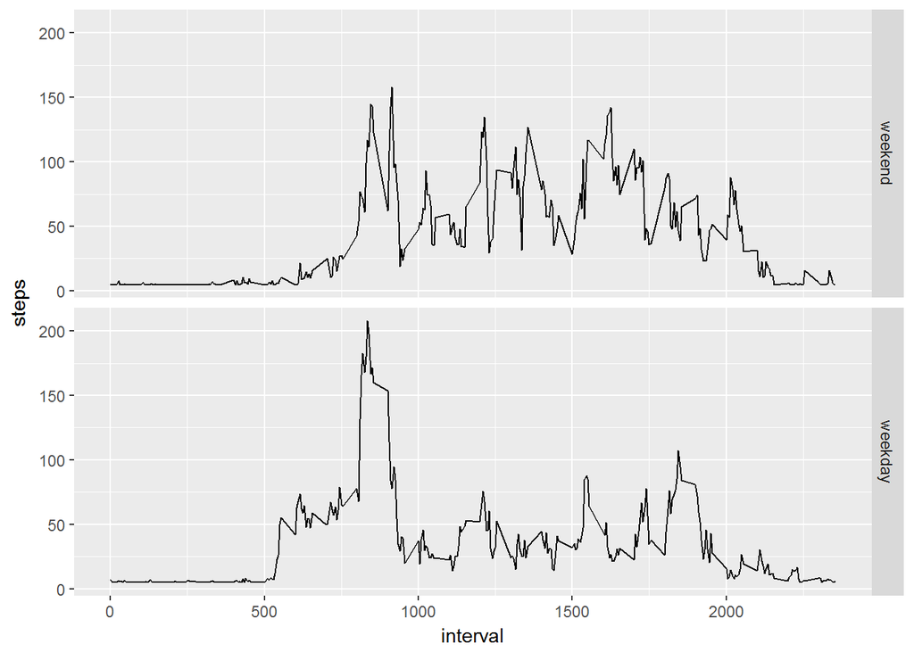

```r
stepsIntervalWeekFactor=aggregate(steps~interval+weekFator,activityFilled,mean)
qplot(y=steps,x=interval,data=stepsIntervalWeekFactor,geom ="line",facets =stepsIntervalWeekFactor$weekFator~.)
```